# Biological data visualization with explicit units

Practical 12: Genomics, systems biology and multi-omics

## Learning objectives

Choose graphics for a defined question; distinguish raw counts, transformed abundance and outcome units; display distributions and design structure.

## Biological question and data

Which plots reveal library-panel size, sample variation and possible confounding in a hypothetical experiment?

No biological download is required. Numerical inputs are hypothetical, not observed animal data. The runnable examples use base R. Count and abundance units are specified where used.

## 1. Inspect the design before the measurements

Count independent animals within the crossed diet/batch design.

**Show R code**

```r
helper_dir <- if (dir.exists("R")) "R" else "../R"
stopifnot(file.exists(file.path(helper_dir,"teaching_data.R")))
source(file.path(helper_dir,"teaching_data.R"))
d <- teaching_data()
meta <- d$metadata
xtabs(~diet+batch,meta)
```

```
            batch
diet          A  B
  control    12 12
  supplement 12 12
```

**Show R code**

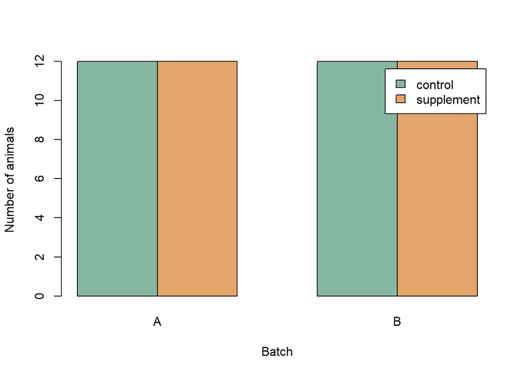

```r
barplot(xtabs(~diet+batch,meta),beside=TRUE,legend.text=TRUE,
 col=c("#86B7A3","#E5A66B"),ylab="Number of animals",xlab="Batch")
```

A balanced cross-tabulation addresses one aspect of design. It does not eliminate every source of confounding.

## 2. Compare count and abundance views

Use exposure-adjusted counts on a descriptive log2 scale for one gene, and already-log2 measurements for a protein.

**Show R code**

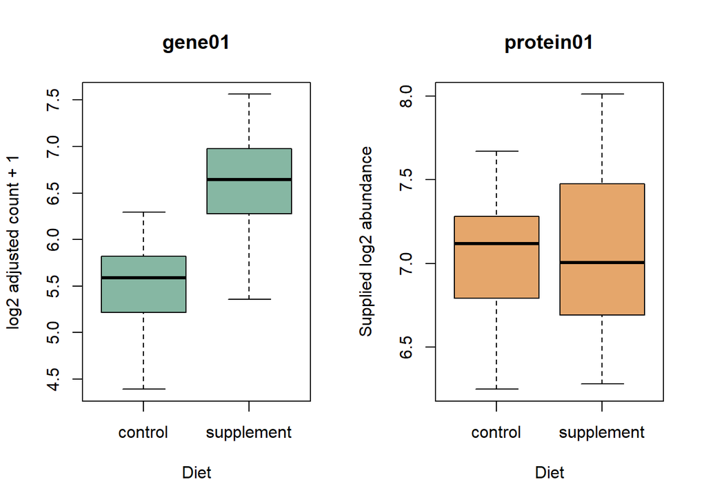

```r
normalized <- sweep(d$counts,2,d$exposure,"/")
par(mfrow=c(1,2))
boxplot(log2(normalized[1,]+1)~meta$diet,xlab="Diet",ylab="log2 adjusted count + 1",
 main="gene01",col="#86B7A3")
boxplot(d$protein[1,]~meta$diet,xlab="Diet",ylab="Supplied log2 abundance",
 main="protein01",col="#E5A66B")
```

**Show R code**

```r
par(mfrow=c(1,1))
```

The axes describe different measurement scales. The gene and protein labels are fictional and their plots do not establish a linked biological mechanism.

## 3. Show outcome distributions and paired measurements

Keep animal alignment explicit and label the outcome units.

**Show R code**

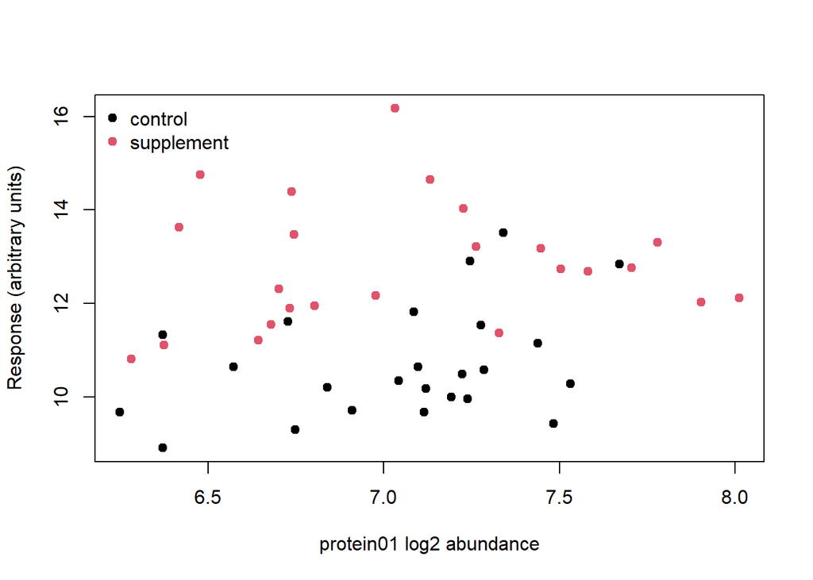

```r
stopifnot(identical(colnames(d$protein),meta$animal))
plot(d$protein[1,],meta$response,col=as.integer(meta$diet),pch=19,
 xlab="protein01 log2 abundance",ylab="Response (arbitrary units)")
legend("topleft",levels(meta$diet),col=1:2,pch=19,bty="n")
```

Colour reveals whether pooled association might combine group shifts and within-group variation.

## 4. Show observations as well as summaries

A group mean can conceal heterogeneity and a small denominator. For these hypothetical values, display every observation beside the group summaries.

**Show R code**

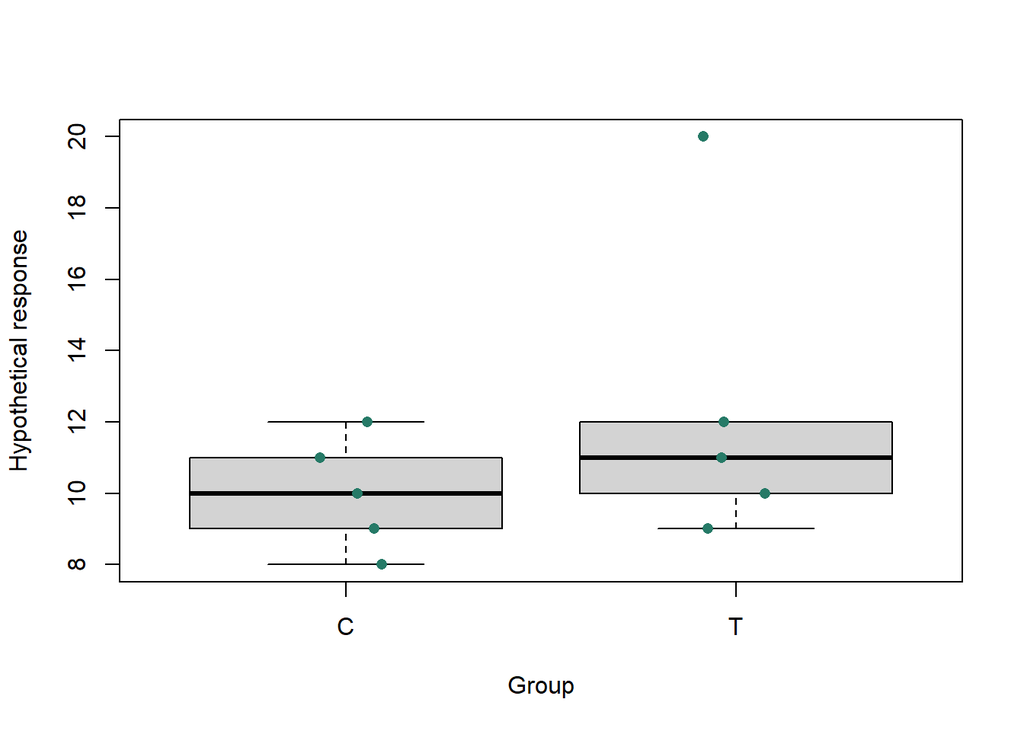

```r
plot_data <- data.frame(group=factor(rep(c('C','T'),each=5)),
 value=c(8,9,10,11,12,9,10,11,12,20))
boxplot(value~group,plot_data,outline=FALSE,ylim=range(plot_data$value),
 xlab='Group',ylab='Hypothetical response')
stripchart(value~group,plot_data,vertical=TRUE,method='jitter',
 add=TRUE,pch=16,col='#267A67')
```

The extreme observation is visible rather than compressed into a bar. Its presence should prompt investigation of records and the model, not automatic exclusion.

## 5. Make comparisons interpretable

Axes should identify units and transformations. A log2 abundance difference, original-scale ratio and raw count describe different quantities. Consistent axes support direct visual comparisons; truncated axes and unequal scales can exaggerate differences.

Use point/interval plots for estimates and uncertainty, sample-level plots for distributions and paired plots when the same animals provide both measurements. Avoid connecting unrelated animals as though they were paired. A figure caption should state the sample unit, subset, transformation and question answered.

## Interpretation challenge

A bar plot shows a strong mean difference but gives no sample counts or uncertainty. What would improve it?

**Suggested reasoning**

Show observations and group denominators, add a justified uncertainty display and identify the units/design. Explain whether the figure is descriptive or displays a fitted contrast.

## Interpretation and limits

Plots diagnose patterns; they do not replace a model or prove an effect. Avoid using different transformations without labelling them, selectively hiding outliers or interpreting one unusual point before checking its identity and processing.

## Exercises

1. Why label the response as arbitrary units?
2. What could a pooled scatterplot hide?
3. Why is a plot of log2 counts not a differential-expression test?

**Suggested answers**

1. The fixture defines no physical calibration for the phenotype.
2. Different relationships within groups, batch shifts or unequal sampling.
3. It supplies neither the required model-based uncertainty nor multiplicity treatment.

## Continue learning

B04 Programming, B06 Transcriptomics and B12 Statistics.

Continue with exploratory multi-omics analysis. Return to the practical index or the unified map.